# riesenberg_assignment_2

Stephen Riesenberg Data Mining Project 2, What's Cooking?

This project comes from the kaggle competition 'What's Cooking?' The goal of the competition is to classify a recipe into one of 20 cuisines based on the ingredients of the recipe. The winner of the competition had an accuracy of about 82%, so my goal will be to see if I can get to 80%.

```python
import pandas as pd
from sklearn.feature_extraction.text import CountVectorizer
from sklearn import preprocessing
from sklearn.naive_bayes import MultinomialNB
from sklearn.model_selection import StratifiedKFold
from sklearn.model_selection import cross_val_score
from sklearn.linear_model import LogisticRegression
from sklearn import svm
from sklearn.ensemble import RandomForestClassifier
from sklearn.neighbors import KNeighborsClassifier
from xgboost import XGBClassifier
from sklearn.model_selection import train_test_split
from sklearn.feature_extraction.text import TfidfVectorizer
import multiprocessing
from gensim.models import Word2Vec
from sklearn.feature_extraction.text import CountVectorizer
import numpy as np
from sklearn.metrics import confusion_matrix
import matplotlib.pyplot as plt
from sklearn import svm, datasets
from sklearn.model_selection import train_test_split
from sklearn.metrics import confusion_matrix
from sklearn.utils.multiclass import unique_labels
import seaborn as sn
import gensim
```

```python
df = pd.read_json('../input/whats-cooking-kernels-only/train.json')
```

Let's see what the data looks like:

```python
df
```

|  | cuisine | id | ingredients |
| --- | --- | --- | --- |
| 0 | greek | 10259 | [romaine lettuce, black olives, grape tomatoes... |
| 1 | southern_us | 25693 | [plain flour, ground pepper, salt, tomatoes, g... |
| 2 | filipino | 20130 | [eggs, pepper, salt, mayonaise, cooking oil, g... |
| 3 | indian | 22213 | [water, vegetable oil, wheat, salt] |
| 4 | indian | 13162 | [black pepper, shallots, cornflour, cayenne pe... |
| 5 | jamaican | 6602 | [plain flour, sugar, butter, eggs, fresh ginge... |
| 6 | spanish | 42779 | [olive oil, salt, medium shrimp, pepper, garli... |
| 7 | italian | 3735 | [sugar, pistachio nuts, white almond bark, flo... |
| 8 | mexican | 16903 | [olive oil, purple onion, fresh pineapple, por... |
| 9 | italian | 12734 | [chopped tomatoes, fresh basil, garlic, extra-... |
| 10 | italian | 5875 | [pimentos, sweet pepper, dried oregano, olive ... |
| 11 | chinese | 45887 | [low sodium soy sauce, fresh ginger, dry musta... |
| 12 | italian | 2698 | [Italian parsley leaves, walnuts, hot red pepp... |
| 13 | mexican | 41995 | [ground cinnamon, fresh cilantro, chili powder... |
| 14 | italian | 31908 | [fresh parmesan cheese, butter, all-purpose fl... |
| 15 | indian | 24717 | [tumeric, vegetable stock, tomatoes, garam mas... |
| 16 | british | 34466 | [greek yogurt, lemon curd, confectioners sugar... |
| 17 | italian | 1420 | [italian seasoning, broiler-fryer chicken, may... |
| 18 | thai | 2941 | [sugar, hot chili, asian fish sauce, lime juice] |
| 19 | vietnamese | 8152 | [soy sauce, vegetable oil, red bell pepper, ch... |
| 20 | thai | 13121 | [pork loin, roasted peanuts, chopped cilantro ... |
| 21 | mexican | 40523 | [roma tomatoes, kosher salt, purple onion, jal... |
| 22 | southern_us | 40989 | [low-fat mayonnaise, pepper, salt, baking pota... |
| 23 | chinese | 29630 | [sesame seeds, red pepper, yellow peppers, wat... |
| 24 | italian | 49136 | [marinara sauce, flat leaf parsley, olive oil,... |
| 25 | chinese | 26705 | [sugar, lo mein noodles, salt, chicken broth, ... |
| 26 | cajun_creole | 27976 | [herbs, lemon juice, fresh tomatoes, paprika, ... |
| 27 | italian | 22087 | [ground black pepper, butter, sliced mushrooms... |
| 28 | chinese | 9197 | [green bell pepper, egg roll wrappers, sweet a... |
| 29 | mexican | 1299 | [flour tortillas, cheese, breakfast sausages, ... |
| ... | ... | ... | ... |
| 39744 | greek | 5680 | [extra-virgin olive oil, oregano, potatoes, ga... |
| 39745 | spanish | 5511 | [quinoa, extra-virgin olive oil, fresh thyme l... |
| 39746 | indian | 32051 | [clove, bay leaves, ginger, chopped cilantro, ... |
| 39747 | moroccan | 5119 | [water, sugar, grated lemon zest, butter, pitt... |
| 39748 | italian | 9526 | [sea salt, pizza doughs, all-purpose flour, co... |
| 39749 | mexican | 45599 | [kosher salt, minced onion, tortilla chips, su... |
| 39750 | mexican | 49670 | [ground black pepper, chicken breasts, salsa, ... |
| 39751 | moroccan | 30735 | [olive oil, cayenne pepper, chopped cilantro f... |
| 39752 | southern_us | 5911 | [self rising flour, milk, white sugar, butter,... |
| 39753 | italian | 33294 | [rosemary sprigs, lemon zest, garlic cloves, g... |
| 39754 | vietnamese | 27082 | [jasmine rice, bay leaves, sticky rice, rotiss... |
| 39755 | indian | 36337 | [mint leaves, cilantro leaves, ghee, tomatoes,... |
| 39756 | mexican | 15508 | [vegetable oil, cinnamon sticks, water, all-pu... |
| 39757 | greek | 34331 | [red bell pepper, garlic cloves, extra-virgin ... |
| 39758 | greek | 47387 | [milk, salt, ground cayenne pepper, ground lam... |
| 39759 | korean | 12153 | [red chili peppers, sea salt, onions, water, c... |
| 39760 | southern_us | 41840 | [butter, large eggs, cornmeal, baking powder, ... |
| 39761 | chinese | 6487 | [honey, chicken breast halves, cilantro leaves... |
| 39762 | indian | 26646 | [curry powder, salt, chicken, water, vegetable... |
| 39763 | italian | 44798 | [fettuccine pasta, low-fat cream cheese, garli... |
| 39764 | mexican | 8089 | [chili powder, worcestershire sauce, celery, r... |
| 39765 | indian | 6153 | [coconut, unsweetened coconut milk, mint leave... |
| 39766 | irish | 25557 | [rutabaga, ham, thick-cut bacon, potatoes, fre... |
| 39767 | italian | 24348 | [low-fat sour cream, grated parmesan cheese, s... |
| 39768 | mexican | 7377 | [shredded cheddar cheese, crushed cheese crack... |
| 39769 | irish | 29109 | [light brown sugar, granulated sugar, butter, ... |
| 39770 | italian | 11462 | [KRAFT Zesty Italian Dressing, purple onion, b... |
| 39771 | irish | 2238 | [eggs, citrus fruit, raisins, sourdough starte... |
| 39772 | chinese | 41882 | [boneless chicken skinless thigh, minced garli... |
| 39773 | mexican | 2362 | [green chile, jalapeno chilies, onions, ground... |

39774 rows × 3 columns

The challenge will be figuring out how to represent the ingredients in such a way that the classifier can work with them. But before we get to that, let's check the distribution of the cuisine, which is our labels:

```python
df.cuisine.value_counts()
```

```
italian         7838
mexican         6438
southern_us     4320
indian          3003
chinese         2673
french          2646
cajun_creole    1546
thai            1539
japanese        1423
greek           1175
spanish          989
korean           830
vietnamese       825
moroccan         821
british          804
filipino         755
irish            667
jamaican         526
russian          489
brazilian        467
Name: cuisine, dtype: int64
```

Our classes are imbalanced, but I don't think this matters too much because we don't care about the minority classes more than the larger classes. Let's get a feel for the ingredients.

```python
def bag_of_words(df):
    # make vocab list
    vocab_dict = {}
    for row in df.ingredients:
        for element in row:
            try:
                vocab_dict[element] += 1
            except KeyError:
                vocab_dict[element] = 1
    return vocab_dict
vocab_dict = bag_of_words(df)
print('Number of ingredients:', len(vocab_dict.keys()))
print('Mean ingredient count:', np.mean(list(vocab_dict.values())))
```

```
Number of ingredients: 6714
Mean ingredient count: 63.7883526958594
```

My first idea for representing the ingredients is to just use one-hot encoding for each ingredient. The downside to this approach is that it won't recognize that 'grilled chicken breast' and 'sliced grilled chicken breast' are basically the same thing, but we'll see how it goes.

```python
# First I encode the labels
le = preprocessing.LabelEncoder()
le.fit(df.cuisine)
X_labels = le.transform(df.cuisine)
```

```python
vectorizer = CountVectorizer(tokenizer=lambda x: [i.strip() for i in x.split(',')])
X = vectorizer.fit_transform(df['ingredients'].apply(','.join))
train, val, train_labels, val_labels = train_test_split(X, X_labels, test_size = 0.1)
pd.DataFrame(train.todense(),columns=vectorizer.get_feature_names()).head()
```

|  |  | ( oz.) tomato sauce | ( oz.) tomato paste | (10 oz.) frozen chopped spinach | (14 oz.) sweetened condensed milk | (14.5 oz.) diced tomatoes | (15 oz.) refried beans | 1 inch thick | 1% low-fat buttermilk | 1% low-fat chocolate milk | 1% low-fat cottage cheese | 1% low-fat milk | 2 1/2 to 3 lb. chicken | 2% low fat cheddar chees | 2% low-fat cottage cheese | 2% lowfat greek yogurt | 2% milk shredded mozzarella cheese | 2% reduced-fat milk | 25% less sodium chicken broth | 33% less sodium cooked deli ham | 33% less sodium cooked ham | 33% less sodium ham | 33% less sodium smoked fully cooked ham | 40% less sodium taco seasoning | 40% less sodium taco seasoning mix | 7 up | 8 ounc ziti pasta | 95% lean ground beef | a taste of thai rice noodles | … |
| --- | --- | --- | --- | --- | --- | --- | --- | --- | --- | --- | --- | --- | --- | --- | --- | --- | --- | --- | --- | --- | --- | --- | --- | --- | --- | --- | --- | --- | --- | --- |
| 0 | 0 | 0 | 0 | 0 | 0 | 0 | 0 | 0 | 0 | 0 | 0 | 0 | 0 | 0 | 0 | 0 | 0 | 0 | 0 | 0 | 0 | 0 | 0 | 0 | 0 | 0 | 0 | 0 | 0 | … |
| 1 | 0 | 0 | 0 | 0 | 0 | 0 | 0 | 0 | 0 | 0 | 0 | 0 | 0 | 0 | 0 | 0 | 0 | 0 | 0 | 0 | 0 | 0 | 0 | 0 | 0 | 0 | 0 | 0 | 0 | … |
| 2 | 0 | 0 | 0 | 0 | 0 | 0 | 0 | 0 | 0 | 0 | 0 | 0 | 0 | 0 | 0 | 0 | 0 | 0 | 0 | 0 | 0 | 0 | 0 | 0 | 0 | 0 | 0 | 0 | 0 | … |
| 3 | 0 | 0 | 0 | 0 | 0 | 0 | 0 | 0 | 0 | 0 | 0 | 0 | 0 | 0 | 0 | 0 | 0 | 0 | 0 | 0 | 0 | 0 | 0 | 0 | 0 | 0 | 0 | 0 | 0 | … |
| 4 | 0 | 0 | 0 | 0 | 0 | 0 | 0 | 0 | 0 | 0 | 0 | 0 | 0 | 0 | 0 | 0 | 0 | 0 | 0 | 0 | 0 | 0 | 0 | 0 | 0 | 0 | 0 | 0 | 0 | … |

Now let's try training some models and see how they do.

```python
clf = LogisticRegression()
clf.fit(train, train_labels)
clf.score(val, val_labels)
```

```
0.7719959778783309
```

```python
clf = MultinomialNB()
clf.fit(train, train_labels)
clf.score(val, val_labels)
```

```
0.7249874308697838
```

```python
clf = XGBClassifier()
clf.fit(train, train_labels)
clf.score(val, val_labels)
```

```
0.6694318753142282
```

Got a pretty good score on the logistic regression already, I'll use that model as the default from here on out. I want to try adjusting some things with the vectorizer, including having it operate on just words instead of phrases.

```python
corpus = []
for key in vocab_dict.keys():
    for word in key.split():
        corpus.append(word)
vectorizer = CountVectorizer()
vectorizer.fit(corpus)
X = vectorizer.transform(df['ingredients'].apply(' '.join))
train, val, train_labels, val_labels = train_test_split(X, X_labels, test_size = 0.1)
pd.DataFrame(train.todense(),columns=vectorizer.get_feature_names()).head()
```

|  | 00 | 10 | 100 | 14 | 15 | 25 | 33 | 40 | 43 | 95 | 96 | abalone | abbamele | absinthe | abura | acai | accent | accompaniment | achiote | acid | acini | ackee | acorn | acting | activ | active | added | adobo | adzuki | … |
| --- | --- | --- | --- | --- | --- | --- | --- | --- | --- | --- | --- | --- | --- | --- | --- | --- | --- | --- | --- | --- | --- | --- | --- | --- | --- | --- | --- | --- | --- | --- |
| 0 | 0 | 0 | 0 | 0 | 0 | 0 | 0 | 0 | 0 | 0 | 0 | 0 | 0 | 0 | 0 | 0 | 0 | 0 | 0 | 0 | 0 | 0 | 0 | 0 | 0 | 0 | 0 | 0 | 0 | … |
| 1 | 0 | 0 | 0 | 0 | 0 | 0 | 0 | 0 | 0 | 0 | 0 | 0 | 0 | 0 | 0 | 0 | 0 | 0 | 0 | 0 | 0 | 0 | 0 | 0 | 0 | 0 | 0 | 0 | 0 | … |
| 2 | 0 | 0 | 0 | 0 | 0 | 0 | 0 | 0 | 0 | 0 | 0 | 0 | 0 | 0 | 0 | 0 | 0 | 0 | 0 | 0 | 0 | 0 | 0 | 0 | 0 | 0 | 0 | 0 | 0 | … |
| 3 | 0 | 0 | 0 | 0 | 0 | 0 | 0 | 0 | 0 | 0 | 0 | 0 | 0 | 0 | 0 | 0 | 0 | 0 | 0 | 0 | 0 | 0 | 0 | 0 | 0 | 0 | 0 | 0 | 0 | … |
| 4 | 0 | 0 | 0 | 0 | 0 | 0 | 0 | 0 | 0 | 0 | 0 | 0 | 0 | 0 | 0 | 0 | 0 | 0 | 0 | 0 | 0 | 0 | 0 | 0 | 0 | 0 | 0 | 0 | 0 | … |

```python
clf = LogisticRegression()
clf.fit(train, train_labels)
clf.score(val, val_labels)
```

```
0.7883358471593765
```

```python
vectorizer = TfidfVectorizer(tokenizer=lambda x: [i.strip() for i in x.split(',')])
X = vectorizer.fit_transform(df['ingredients'].apply(','.join))
train, val, train_labels, val_labels = train_test_split(X, X_labels, test_size = 0.1)
```

```python
clf = LogisticRegression()
clf.fit(train, train_labels)
clf.score(val, val_labels)
```

```
0.7732528908999498
```

TF-IDF also does worse, I don't think our 'documents' -- which are the individual recipes -- are big enough.

Let's change the model back to the best performing model and then make a confusion matrix.

```python
vectorizer = CountVectorizer(tokenizer=lambda x: [i.strip() for i in x.split(',')])
X = vectorizer.fit_transform(df['ingredients'].apply(','.join))
train, val, train_labels, val_labels = train_test_split(X, X_labels, test_size = 0.1)
clf = LogisticRegression()
clf.fit(train, train_labels)
clf.score(val, val_labels)
```

```
0.77526395173454
```

```
Normalized confusion matrix
[[0.55932203 0.         0.01694915 0.         0.03389831 0.01694915
  0.         0.         0.         0.08474576 0.         0.
  0.         0.11864407 0.         0.         0.08474576 0.06779661
  0.01694915 0.        ]
 [0.         0.35869565 0.0326087  0.         0.01086957 0.14130435
  0.         0.06521739 0.07608696 0.09782609 0.02173913 0.
  0.01086957 0.01086957 0.         0.         0.16304348 0.
  0.01086957 0.        ]
 [0.         0.00581395 0.72093023 0.01162791 0.         0.04069767
  0.         0.         0.00581395 0.04069767 0.         0.
  0.         0.03488372 0.         0.         0.13372093 0.00581395
  0.         0.        ]
 [0.         0.         0.00766284 0.85440613 0.01149425 0.00383142
  0.00383142 0.00766284 0.         0.02298851 0.00383142 0.01532567
  0.01915709 0.         0.         0.         0.01915709 0.
  0.02681992 0.00383142]
 [0.03896104 0.         0.         0.1038961  0.5974026  0.01298701
  0.         0.02597403 0.         0.03896104 0.         0.
  0.01298701 0.03896104 0.         0.         0.07792208 0.
  0.03896104 0.01298701]
 [0.         0.0083682  0.0125523  0.0041841  0.0083682  0.58577406
  0.0041841  0.0125523  0.0292887  0.22175732 0.0041841  0.
  0.         0.0251046  0.         0.         0.07112971 0.0125523
  0.         0.        ]
 [0.         0.         0.         0.         0.         0.05785124
  0.61983471 0.00826446 0.         0.24793388 0.         0.
  0.         0.01652893 0.02479339 0.         0.01652893 0.00826446
  0.         0.        ]
 [0.         0.         0.         0.01351351 0.         0.
  0.01351351 0.89189189 0.         0.01013514 0.00675676 0.00675676
  0.         0.02364865 0.02027027 0.00337838 0.00675676 0.
  0.00337838 0.        ]
 [0.         0.07017544 0.         0.         0.01754386 0.12280702
  0.         0.         0.54385965 0.0877193  0.         0.01754386
  0.         0.         0.         0.         0.14035088 0.
  0.         0.        ]
 [0.         0.00518135 0.00647668 0.         0.         0.04015544
  0.01036269 0.00129534 0.00129534 0.88601036 0.         0.
  0.         0.01165803 0.00129534 0.         0.03108808 0.00388601
```

[output cut: 26 more lines]

```
  0.00240385 0.00480769 0.00240385 0.04086538 0.00961538 0.
  0.         0.03846154 0.00240385 0.00240385 0.80769231 0.00480769
  0.         0.        ]
 [0.01030928 0.01030928 0.01030928 0.         0.03092784 0.1443299
  0.02061856 0.01030928 0.         0.2371134  0.         0.01030928
  0.         0.11340206 0.01030928 0.01030928 0.05154639 0.31958763
  0.01030928 0.        ]
 [0.01265823 0.         0.00632911 0.01898734 0.00632911 0.00632911
  0.00632911 0.02531646 0.         0.00632911 0.         0.01265823
  0.         0.03164557 0.         0.         0.         0.
  0.80379747 0.06329114]
 [0.01388889 0.         0.         0.11111111 0.02777778 0.01388889
  0.         0.         0.         0.02777778 0.         0.01388889
  0.01388889 0.         0.01388889 0.         0.01388889 0.
  0.23611111 0.51388889]]
```

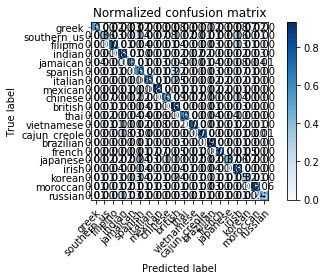

```python
# got this plot_confusion_matrix function from sklearn documentation
def plot_confusion_matrix(y_true, y_pred, classes,
                          normalize=False,
                          title=None,
                          cmap=plt.cm.Blues):
    """
    This function prints and plots the confusion matrix.
    Normalization can be applied by setting `normalize=True`.
    """
    if not title:
        if normalize:
            title = 'Normalized confusion matrix'
        else:
            title = 'Confusion matrix, without normalization'

    # Compute confusion matrix
    cm = confusion_matrix(y_true, y_pred)
    # Only use the labels that appear in the data
    classes = classes[unique_labels(y_true, y_pred)]
    if normalize:
        cm = cm.astype('float') / cm.sum(axis=1)[:, np.newaxis]
        print("Normalized confusion matrix")
    else:
        print('Confusion matrix, without normalization')

    print(cm)

    fig, ax = plt.subplots()
    im = ax.imshow(cm, interpolation='nearest', cmap=cmap)
    ax.figure.colorbar(im, ax=ax)
    # We want to show all ticks...
    ax.set(xticks=np.arange(cm.shape[1]),
           yticks=np.arange(cm.shape[0]),
           # ... and label them with the respective list entries
           xticklabels=classes, yticklabels=classes,
           title=title,
           ylabel='True label',
           xlabel='Predicted label')

    # Rotate the tick labels and set their alignment.
    plt.setp(ax.get_xticklabels(), rotation=45, ha="right",
             rotation_mode="anchor")

    # Loop over data dimensions and create text annotations.
    fmt = '.2f' if normalize else 'd'
    thresh = cm.max() / 2.
    for i in range(cm.shape[0]):
        for j in range(cm.shape[1]):
            ax.text(j, i, format(cm[i, j], fmt),
                    ha="center", va="center",
                    color="white" if cm[i, j] > thresh else "black")
    fig.tight_layout()
    return ax
predictions = (clf.predict(val))
classes = df.cuisine.unique()
plot_confusion_matrix(val_labels, predictions, classes, normalize = True)
```

This matrix is super ugly, trying seaborn to see if it's prettier.

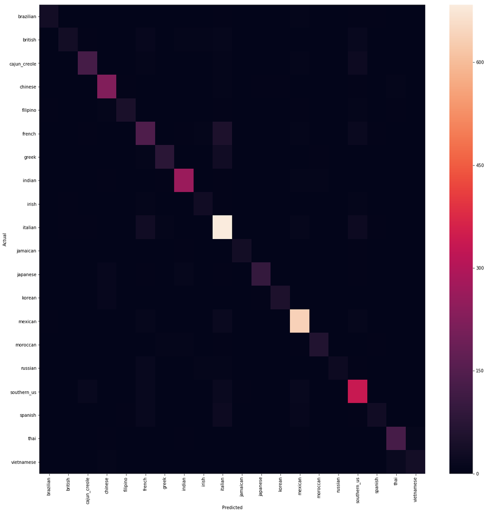

```python
labels = le.inverse_transform(clf.classes_)
cm = confusion_matrix(le.inverse_transform(val_labels), le.inverse_transform(clf.predict(val)), labels = labels)
cm = pd.DataFrame(cm, index=labels, columns=labels)
cm.index.name = 'Actual'
cm.columns.name = 'Predicted'
fig, ax = plt.subplots(figsize=(20,20))
sn.heatmap(cm)
```

That looks better, but it doesn't provide too much insight into how we could improve the model.

I want to try a couple more things: Treating salt as a stop word because it is by far the most common ingredient Exploring word2vec

```python
print(len(vectorizer.get_feature_names()))
vectorizer = CountVectorizer(tokenizer=lambda x: [i.strip() for i in x.split(',')], stop_words=['salt'])
vectorizer.fit(list(vocab_dict.keys()))
X = vectorizer.transform(df['ingredients'].apply(','.join))
train, val, train_labels, val_labels = train_test_split(X, X_labels, test_size = 0.1)
len(vectorizer.get_feature_names())
```

```
6712
```

```
6711
```

```python
clf = LogisticRegression()
clf.fit(train, train_labels)
clf.score(val, val_labels)
```

```
0.779788838612368
```

Looks like it didn't help.

For word2vec, first I'm going to try using the pretrained model.

```python
w2v_model = gensim.models.KeyedVectors.load_word2vec_format('../input/nlpword2vecembeddingspretrained/GoogleNews-vectors-negative300.bin', binary=True)
```

Now that I think about it more, I don't know how to actually use these vectors, my only idea is to take the mean of the vectors of the ingredients.

```python
def get_mean_vector(ingredient_list):
    vector_list = []
    vocab_missing = []
    for i in ingredient_list:
        for j in i.split():
            try:
                vector_list.append(w2v_model[j])
            except KeyError:
                pass
    vector_list = np.asarray(vector_list)
    return np.mean(vector_list, axis = 0)

get_mean_vector(df.ingredients[2])
```

[output not shown]

```python
w2v_df = df.copy()
w2v_df['mean_vector'] = w2v_df.ingredients.apply(get_mean_vector)
# https://stackoverflow.com/questions/35491274/pandas-split-column-of-lists-into-multiple-columns
```

```python
one_hot_df = pd.DataFrame(w2v_df['mean_vector'].values.tolist())
w2v_df = pd.concat([w2v_df, one_hot_df], axis = 1)
```

```python
X = w2v_df.drop(['cuisine', 'id', 'ingredients', 'mean_vector'], axis = 1)
```

```python
train, val, train_labels, val_labels = train_test_split(X, X_labels, test_size = 0.1)
```

```python
clf = LogisticRegression()
clf.fit(train, train_labels)
clf.score(val, val_labels)
```

```
0.7116641528406235
```

```python
clf = XGBClassifier()
clf.fit(train, train_labels)
clf.score(val, val_labels)
```

```
0.6681749622926093
```

Using mean word2vec vectors performs worse than our one-hot encoding. But, it's also possible to train our own word2vec model, now I'm going to try that.

```python
w2v_trained = Word2Vec(min_count=2,
                     window=3,
                     size=100,
                     sample=6e-5,
                     alpha=0.03,
                     min_alpha=0.0007,
                     negative=20,
                     workers=3)
```

```python
w2v_trained.build_vocab(df['ingredients'].values.tolist())
```

```python
w2v_trained.train(df['ingredients'].values.tolist(), total_examples=w2v_trained.corpus_count, epochs=30, report_delay=1)
```

```
(4378099, 12848250)
```

```python
def get_mean_vector_trainedw2v(ingredient_list):
    vector_list = []
    vocab_missing = []
    for i in ingredient_list:
        for j in i.split():
            try:
                vector_list.append(w2v_trained[j])
            except KeyError:
                pass
    vector_list = np.asarray(vector_list)
    if len(vector_list) > 1:
        return np.mean(vector_list, axis = 0)
    elif len(vector_list) == 1:
        return vector_list[0]
    else:
        return None
```

```python
new_w2v = df.copy()
new_w2v['mean_vector'] = new_w2v.ingredients.apply(get_mean_vector_trainedw2v)
new_w2v = new_w2v.dropna()
vector_df = pd.DataFrame(new_w2v['mean_vector'].values.tolist())
new_w2v = pd.concat([new_w2v, vector_df], axis = 1)
new_w2v = new_w2v.dropna()
le = preprocessing.LabelEncoder()
le.fit(new_w2v.cuisine)
X_labels = le.transform(new_w2v.cuisine)
X = new_w2v.drop(['cuisine', 'id', 'ingredients', 'mean_vector'], axis = 1)
train, val, train_labels, val_labels = train_test_split(X, X_labels, test_size = 0.1)
clf = LogisticRegression()
clf.fit(train, train_labels)
clf.score(val, val_labels)
```

```
0.2112144832788534
```

```python
le = preprocessing.LabelEncoder()
le.fit(df.cuisine)
X_labels = le.transform(df.cuisine)
vectorizer = CountVectorizer(tokenizer=lambda x: [i.strip() for i in x.split(',')])
X = vectorizer.fit_transform(df['ingredients'].apply(','.join))
clf = LogisticRegression()
clf.fit(X, X_labels)
```

```
LogisticRegression(C=1.0, class_weight=None, dual=False, fit_intercept=True,
          intercept_scaling=1, max_iter=100, multi_class='warn',
          n_jobs=None, penalty='l2', random_state=None, solver='warn',
          tol=0.0001, verbose=0, warm_start=False)
```

```python
test_df = pd.read_json('../input/whats-cooking-kernels-only/test.json')
Y = vectorizer.transform(test_df['ingredients'].apply(','.join))
submission = test_df.copy()
submission['cuisine'] = le.inverse_transform(clf.predict(Y))
submission[['id', 'cuisine']].to_csv('logregsubmission.csv', index = False)
```